# HomeWork2_TOD_PolicyBrief

### Wrangling Transit Open Data

LA county/city’s main trail routes data resource: https://github.com/datadesk/lametro-maps

```r
#get trail stations data

green_station <- st_read("C:/Users/25077/Desktop/MUSA 508_PPA/3_/Geojsonb/green-line-stations.geojson")
gold_station <- st_read("C:/Users/25077/Desktop/MUSA 508_PPA/3_/Geojsonb/gold-line-stations.geojson")
blue_station <- st_read("C:/Users/25077/Desktop/MUSA 508_PPA/3_/Geojsonb/blue-line-stations.geojson")
expo_station <- st_read("C:/Users/25077/Desktop/MUSA 508_PPA/3_/Geojsonb/expo-line-stations.geojson")
RedPurple_station <- st_read("C:/Users/25077/Desktop/MUSA 508_PPA/3_/Geojsonb/red-and-purple.geojson")


#combine into 1 data frame but noted with different context in another column

LA_Stops <-
  rbind(
     green_station %>%
      mutate(Line2 = "green_station") %>%
      dplyr::select(STATION, LINE, Line2),
     gold_station %>%
      mutate(Line2 ="gold_station") %>%
      dplyr::select(STATION, LINE, Line2),
     blue_station %>%
      mutate(Line2 ="blue_station") %>%
      dplyr::select(STATION, LINE, Line2),
     expo_station %>%
      mutate(Line2 ="expo_station") %>%
      dplyr::select(STATION, LINE, Line2),
     RedPurple_station %>%
      mutate(Line2 ="redPurple_station") %>%
      dplyr::select(STATION, LINE, Line2)) %>%
  st_transform(st_crs(tracts09))


#clip the stations to fit into the city's boundary

LA_Stops_city <- st_intersection(LA_Stops, LACity_Refer)
```

LA city is transforming its approach to urban development with a focus on Transit Oriented Development (TOD), centering growth around its expanding public transit system. Managed by the Los Angeles County Metropolitan Transportation Authority, the network includes subways, light-rails, and buses. TOD aims to create vibrant, walkable communities that capitalize on the proximity to transit stations, aiming to boost property values, reduce traffic, and promote sustainable living. As the city progresses, evaluating the impact of TOD is crucial for guiding future investments and ensuring that development meets the evolving needs of its residents.

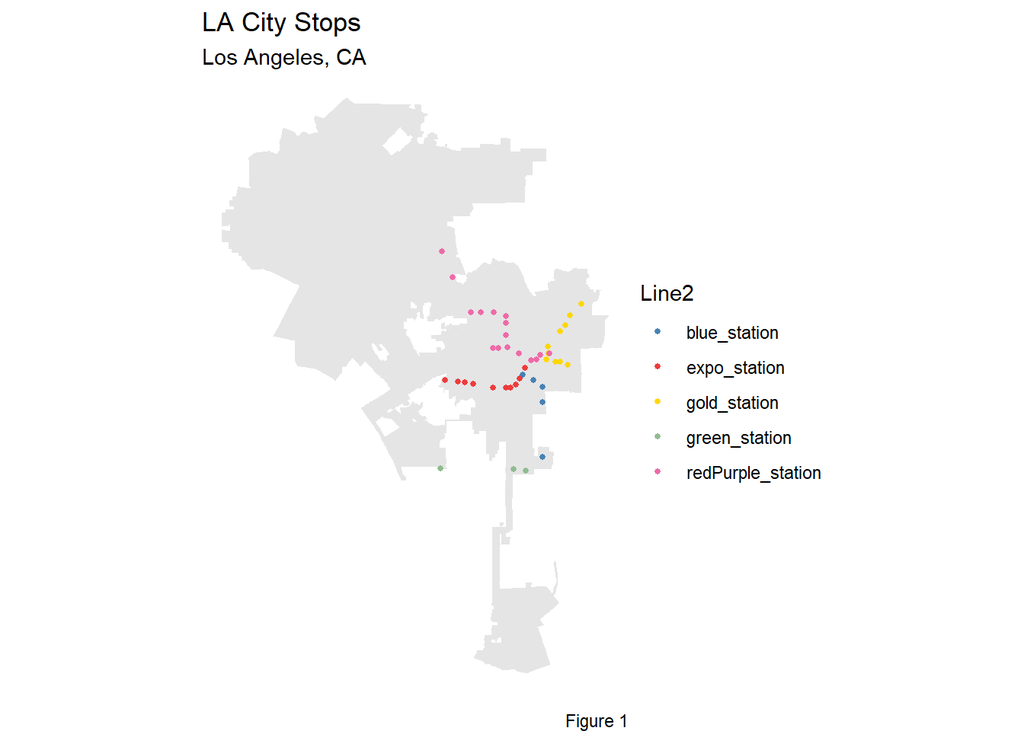

```r
ggplot() +
  geom_sf(data=st_union(tracts09_city), color = NA) +
  geom_sf(data=LA_Stops_city,
          aes(colour = Line2),
          show.legend = "point", size= 1) +
  scale_color_manual(values = c("blue_station" = "steelblue",
                                "expo_station" = "brown2",
                                "gold_station" = "gold",
                                "green_station" = "darkseagreen",
                                "redPurple_station" = "hotpink2")) +
  labs(title="LA City Stops",
       subtitle="Los Angeles, CA",
       caption="Figure 1") +
  theme_void()
```

In this framework, neighborhoods within a half-mile radius of public transit stations are strategically classified as TOD zones, fostering environments where sustainable practices and transit accessibility are paramount.

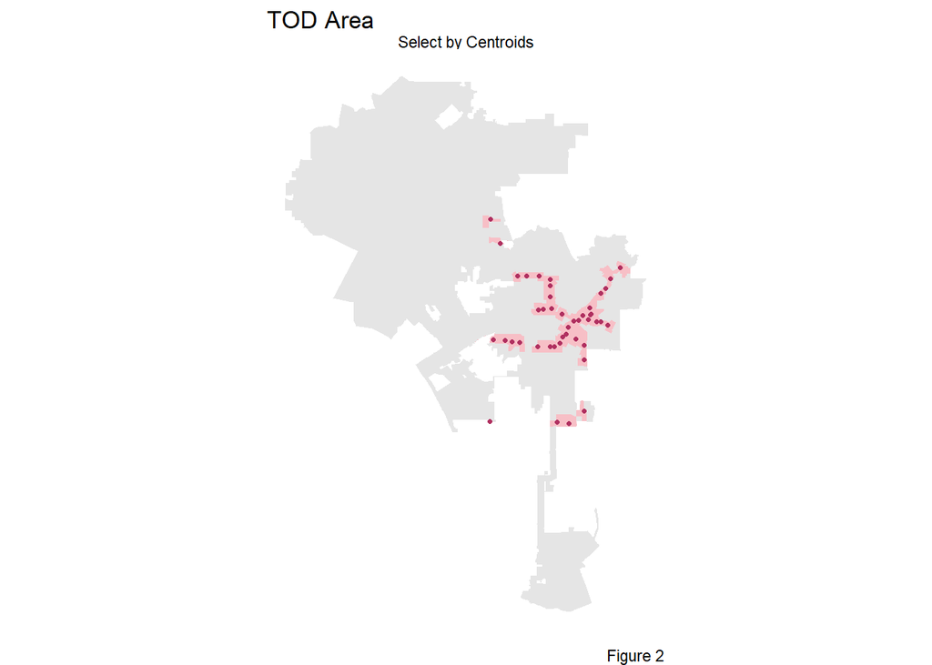

```r
#buffer the stops r=2640 feet
stopBuffer <- st_buffer(LA_Stops_city, 2640)

#removing overlaps and forming a single shape
stopUnion <- st_union(st_buffer(LA_Stops_city, 2640))

LA_Stops_Buffers <-
  rbind(
     stopBuffer %>%
      mutate(Legend = "Buffer") %>%
      dplyr::select(Legend),
     stopUnion %>%
      st_sf() %>%
      mutate(Legend = "Unioned Buffer"))

buffer <- filter(LA_Stops_Buffers, Legend=="Unioned Buffer")

#select the tracts have centroids within the buffer area
#Identified as the TOD area

selectCentroids <-
  st_centroid(tracts09_city)[buffer,] %>%
  st_drop_geometry() %>%
  left_join(., dplyr::select(tracts09_city, GEOID), by = "GEOID") %>%
  st_sf() %>%
  dplyr::select(TotalPop,GEOID) %>%
  mutate(Selection_Type = "Select by Centroids")

#plot the service area

ggplot() +
  geom_sf(data=tracts09_city, color=NA) +
  geom_sf(data=selectCentroids, fill='lightpink1', alpha=0.7, color = NA) +
  geom_sf(data=LA_Stops_city, show.legend = TRUE,color='maroon', size=0.9) +
  facet_wrap(~Selection_Type) +
  labs(fill = "ACS estimate",
       title="TOD Area",
       caption="Figure 2") +
  theme_void()
```